# Karls_data

## · PR: logistic regression diagnostics

Logistic regression assumptions differ from linear regression. We check for linearity, multicollinearity, complete separation, overall goodness of fit, and influential observations.

```r
# Box-Tidwell test: checks whether continuous predictors have a linear relationship
# with the log-odds of PR. Interaction term age:log(age) should be non-significant.
df_bt <- df |>
  filter(!is.na(age), !is.na(sex)) |>
  mutate(age_log_age = age * log(age))

glm_bt <- glm(PR ~ treatment + age + sex + age_log_age,
              data = df_bt, family = binomial)

bt_coef <- tidy(glm_bt) |> filter(term == "age_log_age")
cat(sprintf(
  "Box-Tidwell interaction (age × log(age)): beta = %.4f, p = %.4f\n",
  bt_coef$estimate, bt_coef$p.value
))
```

```
## Box-Tidwell interaction (age × log(age)): beta = 1.4778, p = 0.0462
```

The Box-Tidwell test is borderline significant (β = 1.48, p = 0.046), suggesting a possible non-linear relationship between age and the log-odds of PR, though the small sample size warrants cautious interpretation.

```r
# Check for complete or quasi-complete separation — a common issue with binary outcomes
# If any cell in the cross-tab is 0, separation may be present
cat("Cross-tabulation of treatment by PR:\n")
```

```
## Cross-tabulation of treatment by PR:
```

```r
print(table(df$treatment, df$PR))
```

```
##
##     no yes
##   A 15  17
##   B 10  19
##   C 24  15
```

```r
cat("\nCross-tabulation of sex by PR:\n")
```

```
##
## Cross-tabulation of sex by PR:
```

```r
print(table(df$sex, df$PR))
```

```
##
##          no yes
##   Female 25  26
##   Male   24  25
```

All cells are non-zero across both cross-tabulations (minimum cell count = 10), so there is no evidence of complete or quasi-complete separation.

```r
# Hosmer-Lemeshow goodness-of-fit test
# H0: the model fits adequately; p > 0.05 is desired
hl_test <- hoslem.test(
  x = glm_pr_main$y,       # 直接从模型对象取，长度保证一致
  y = fitted(glm_pr_main),
  g = 10
)
cat(sprintf(
  "Hosmer-Lemeshow test: X² = %.4f, df = %d, p = %.4f\n",
  hl_test$statistic, hl_test$parameter, hl_test$p.value
))
```

```
## Hosmer-Lemeshow test: X² = 8.6131, df = 8, p = 0.3760
```

The Hosmer-Lemeshow test is non-significant (χ² = 8.61, df = 8, p = 0.376), indicating adequate model fit.

```r
# Variance Inflation Factors for the PR model
vif_pr <- vif(glm_pr_main)
cat("VIF values (PR model):\n")
```

```
## VIF values (PR model):
```

```r
print(round(vif_pr, 3))
```

```
##            GVIF Df GVIF^(1/(2*Df))
## treatment 1.031  2           1.008
## age       1.146  1           1.071
## sex       1.122  1           1.059
```

All GVIF^(1/(2·Df)) values are close to 1 (treatment: 1.008, age: 1.071, sex: 1.059), indicating no meaningful multicollinearity.

```r
# Cook's distance — identify influential observations
cooksd_pr <- cooks.distance(glm_pr_main)
influential_pr <- which(cooksd_pr > 4 / nrow(df))   # common rule of thumb: 4/n

cat(sprintf(
  "Number of potentially influential observations (Cook's D > 4/n): %d\n",
  length(influential_pr)
))
```

```
## Number of potentially influential observations (Cook's D > 4/n): 7
```

```r
if (length(influential_pr) > 0) {
  cat("Participant IDs:", paste(df$ID[influential_pr], collapse = ", "), "\n")
}
```

```
## Participant IDs: 16, 40, 49, 57, 72, 82, 92
```

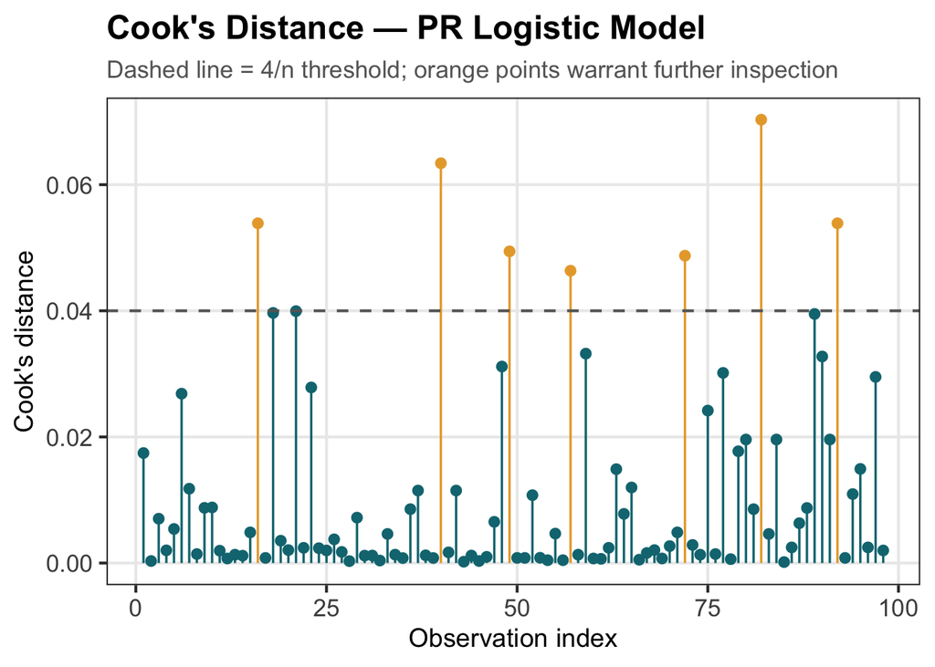

```r
# Visualise Cook's distances
tibble(
  obs     = seq_along(cooksd_pr),
  cooksd  = cooksd_pr,
  flagged = cooksd_pr > 4 / nrow(df)
) |>
  ggplot(aes(x = obs, y = cooksd, colour = flagged)) +
  geom_segment(aes(xend = obs, yend = 0), linewidth = 0.6) +
  geom_point(size = 2) +
  geom_hline(yintercept = 4 / nrow(df),
             linetype = "dashed", colour = "grey40") +
  scale_colour_manual(values = c(`FALSE` = "#0D7680", `TRUE` = "#E8A838"),
                      guide  = "none") +
  labs(
    title    = "Cook's Distance — PR Logistic Model",
    subtitle = "Dashed line = 4/n threshold; orange points warrant further inspection",
    x        = "Observation index",
    y        = "Cook's distance"
  ) +
  theme_ppt
```

```r
save_ppt_fig("ppt_pr_cooks.png", width = 9, height = 5)
```

# Others

## Reproduce Jono Plot

```r
whisker_data <- df |>
  filter(!is.na(AF), !is.na(sex)) |>
  group_by(treatment, sex) |>
  mutate(
    Q1    = quantile(AF, 0.25),
    Q3    = quantile(AF, 0.75),
    IQR   = Q3 - Q1,
    lower = min(AF[AF >= Q1 - 1.5 * IQR]),
    upper = max(AF[AF <= Q3 + 1.5 * IQR])
  ) |>
  filter(AF == lower | AF == upper) |>
  ungroup()

p <- ggplot(df |> filter(!is.na(AF), !is.na(sex)),
            aes(x = treatment, y = AF, fill = sex, colour = sex)) +
  geom_boxplot(
    aes(group = interaction(treatment, sex)),
    position      = position_dodge(width = 0.8),
    width         = 0.6,
    alpha         = 0.85,
    color         = "black"
  ) +
  stat_summary(
    aes(group = interaction(treatment, sex)),
    fun      = mean,
    geom     = "point",
    shape    = 22,
    size     = 3,
    fill     = "white",
    color    = "black",
    position = position_dodge(width = 0.8)
  ) +
  geom_text(
    data        = whisker_data,
    aes(label   = paste0("ID: ", ID)),
    position    = position_dodge(width = 0.8),
    size        = 3,
    family      = "Times New Roman",
    hjust       = -0.15,
    show.legend = FALSE
  ) +
  scale_fill_manual(values   = c(Female = "#2E86AB", Male = "#A0522D")) +
  scale_colour_manual(values = c(Female = "#2E86AB", Male = "#A0522D")) +
  labs(
    title    = "Boxplot of AF against treatment",
    subtitle = "White squares are sample means",
    x        = "Treatment",
    y        = "Activating factor",
    fill     = "sex",
    colour   = "sex"
  ) +
  theme_bw(base_size = 13, base_family = "Times New Roman") +
  theme(
    plot.title       = element_text(face = "bold", family = "Times New Roman"),
    plot.subtitle    = element_text(family = "Times New Roman"),
    axis.title       = element_text(family = "Times New Roman"),
    axis.text        = element_text(family = "Times New Roman"),
    legend.title     = element_text(family = "Times New Roman"),
    legend.text      = element_text(family = "Times New Roman"),
    legend.position  = "top",
    panel.grid = element_blank(),
    panel.border   = element_blank(),
    axis.line.x    = element_line(colour = "black"),
    axis.line.y    = element_line(colour = "black")
  )

ggsave(
  filename    = here("figs", "af_by_treatment_sex.tiff"),
  plot        = p,
  width       = 9,
  height      = 6,
  dpi         = 500,
  device      = "tiff",
  compression = "lzw"
)
```